# Risk Factor Analysis

## Outcome Variable

**Outcome Variable:** sstunted

## Predictor Variables

**Intervention Variable:** hfoodsec

**Adjustment Set:**

unadjusted

## Stratifying Variables

The analysis was stratified on these variable(s):

- agecat
- studyid
- country

## Data Summary

| agecat | studyid | country | hfoodsec | sstunted | n_cell | n | outcome_variable |
| --- | --- | --- | --- | --- | --- | --- | --- |
| Birth | ki0047075b-MAL-ED | BANGLADESH | Food Secure | 0 | 140 | 172 | sstunted |
| Birth | ki0047075b-MAL-ED | BANGLADESH | Food Secure | 1 | 4 | 172 | sstunted |
| Birth | ki0047075b-MAL-ED | BANGLADESH | Mildly Food Insecure | 0 | 3 | 172 | sstunted |
| Birth | ki0047075b-MAL-ED | BANGLADESH | Mildly Food Insecure | 1 | 1 | 172 | sstunted |
| Birth | ki0047075b-MAL-ED | BANGLADESH | Food Insecure | 0 | 23 | 172 | sstunted |
| Birth | ki0047075b-MAL-ED | BANGLADESH | Food Insecure | 1 | 1 | 172 | sstunted |
| Birth | ki0047075b-MAL-ED | BRAZIL | Food Secure | 0 | 0 | 28 | sstunted |
| Birth | ki0047075b-MAL-ED | BRAZIL | Food Secure | 1 | 0 | 28 | sstunted |
| Birth | ki0047075b-MAL-ED | BRAZIL | Mildly Food Insecure | 0 | 4 | 28 | sstunted |
| Birth | ki0047075b-MAL-ED | BRAZIL | Mildly Food Insecure | 1 | 0 | 28 | sstunted |
| Birth | ki0047075b-MAL-ED | BRAZIL | Food Insecure | 0 | 22 | 28 | sstunted |
| Birth | ki0047075b-MAL-ED | BRAZIL | Food Insecure | 1 | 2 | 28 | sstunted |
| Birth | ki0047075b-MAL-ED | INDIA | Food Secure | 0 | 32 | 37 | sstunted |
| Birth | ki0047075b-MAL-ED | INDIA | Food Secure | 1 | 2 | 37 | sstunted |
| Birth | ki0047075b-MAL-ED | INDIA | Mildly Food Insecure | 0 | 1 | 37 | sstunted |
| Birth | ki0047075b-MAL-ED | INDIA | Mildly Food Insecure | 1 | 0 | 37 | sstunted |
| Birth | ki0047075b-MAL-ED | INDIA | Food Insecure | 0 | 2 | 37 | sstunted |
| Birth | ki0047075b-MAL-ED | INDIA | Food Insecure | 1 | 0 | 37 | sstunted |
| Birth | ki0047075b-MAL-ED | NEPAL | Food Secure | 0 | 10 | 14 | sstunted |
| Birth | ki0047075b-MAL-ED | NEPAL | Food Secure | 1 | 0 | 14 | sstunted |
| Birth | ki0047075b-MAL-ED | NEPAL | Mildly Food Insecure | 0 | 1 | 14 | sstunted |
| Birth | ki0047075b-MAL-ED | NEPAL | Mildly Food Insecure | 1 | 0 | 14 | sstunted |
| Birth | ki0047075b-MAL-ED | NEPAL | Food Insecure | 0 | 3 | 14 | sstunted |
| Birth | ki0047075b-MAL-ED | NEPAL | Food Insecure | 1 | 0 | 14 | sstunted |
| Birth | ki0047075b-MAL-ED | PERU | Food Secure | 0 | 24 | 91 | sstunted |
| Birth | ki0047075b-MAL-ED | PERU | Food Secure | 1 | 0 | 91 | sstunted |
| Birth | ki0047075b-MAL-ED | PERU | Mildly Food Insecure | 0 | 23 | 91 | sstunted |
| Birth | ki0047075b-MAL-ED | PERU | Mildly Food Insecure | 1 | 0 | 91 | sstunted |
| Birth | ki0047075b-MAL-ED | PERU | Food Insecure | 0 | 44 | 91 | sstunted |
| Birth | ki0047075b-MAL-ED | PERU | Food Insecure | 1 | 0 | 91 | sstunted |

[output cut: 168 more lines]

The following strata were considered:

- agecat: 24 months, studyid: ki0047075b-MAL-ED, country: BANGLADESH
- agecat: 24 months, studyid: ki0047075b-MAL-ED, country: BRAZIL
- agecat: 24 months, studyid: ki0047075b-MAL-ED, country: INDIA
- agecat: 24 months, studyid: ki0047075b-MAL-ED, country: NEPAL
- agecat: 24 months, studyid: ki0047075b-MAL-ED, country: PERU
- agecat: 24 months, studyid: ki0047075b-MAL-ED, country: SOUTH AFRICA
- agecat: 24 months, studyid: ki1017093-NIH-Birth, country: BANGLADESH
- agecat: 24 months, studyid: ki1017093c-NIH-Crypto, country: BANGLADESH
- agecat: 24 months, studyid: ki1113344-GMS-Nepal, country: NEPAL
- agecat: 24 months, studyid: kiGH5241-JiVitA-3, country: BANGLADESH
- agecat: 24 months, studyid: kiGH5241-JiVitA-4, country: BANGLADESH
- agecat: 6 months, studyid: ki0047075b-MAL-ED, country: BANGLADESH
- agecat: 6 months, studyid: ki0047075b-MAL-ED, country: BRAZIL
- agecat: 6 months, studyid: ki0047075b-MAL-ED, country: INDIA
- agecat: 6 months, studyid: ki0047075b-MAL-ED, country: NEPAL
- agecat: 6 months, studyid: ki0047075b-MAL-ED, country: PERU
- agecat: 6 months, studyid: ki0047075b-MAL-ED, country: SOUTH AFRICA
- agecat: 6 months, studyid: ki1017093-NIH-Birth, country: BANGLADESH
- agecat: 6 months, studyid: ki1017093c-NIH-Crypto, country: BANGLADESH
- agecat: 6 months, studyid: ki1113344-GMS-Nepal, country: NEPAL
- agecat: 6 months, studyid: kiGH5241-JiVitA-3, country: BANGLADESH
- agecat: 6 months, studyid: kiGH5241-JiVitA-4, country: BANGLADESH
- agecat: Birth, studyid: ki0047075b-MAL-ED, country: BANGLADESH
- agecat: Birth, studyid: ki0047075b-MAL-ED, country: BRAZIL
- agecat: Birth, studyid: ki0047075b-MAL-ED, country: INDIA
- agecat: Birth, studyid: ki0047075b-MAL-ED, country: NEPAL
- agecat: Birth, studyid: ki0047075b-MAL-ED, country: PERU
- agecat: Birth, studyid: ki0047075b-MAL-ED, country: SOUTH AFRICA
- agecat: Birth, studyid: ki1017093-NIH-Birth, country: BANGLADESH
- agecat: Birth, studyid: ki1017093c-NIH-Crypto, country: BANGLADESH
- agecat: Birth, studyid: ki1113344-GMS-Nepal, country: NEPAL
- agecat: Birth, studyid: kiGH5241-JiVitA-3, country: BANGLADESH
- agecat: Birth, studyid: kiGH5241-JiVitA-4, country: BANGLADESH

### Dropped Strata

Some strata were dropped due to rare outcomes:

- agecat: Birth, studyid: ki0047075b-MAL-ED, country: BANGLADESH
- agecat: Birth, studyid: ki0047075b-MAL-ED, country: BRAZIL
- agecat: Birth, studyid: ki0047075b-MAL-ED, country: INDIA
- agecat: Birth, studyid: ki0047075b-MAL-ED, country: NEPAL
- agecat: Birth, studyid: ki0047075b-MAL-ED, country: PERU
- agecat: Birth, studyid: ki0047075b-MAL-ED, country: SOUTH AFRICA
- agecat: Birth, studyid: ki1017093-NIH-Birth, country: BANGLADESH
- agecat: Birth, studyid: ki1017093c-NIH-Crypto, country: BANGLADESH
- agecat: 6 months, studyid: ki0047075b-MAL-ED, country: BANGLADESH
- agecat: 6 months, studyid: ki0047075b-MAL-ED, country: BRAZIL
- agecat: 6 months, studyid: ki0047075b-MAL-ED, country: INDIA
- agecat: 6 months, studyid: ki0047075b-MAL-ED, country: NEPAL
- agecat: 6 months, studyid: ki0047075b-MAL-ED, country: PERU
- agecat: 6 months, studyid: ki0047075b-MAL-ED, country: SOUTH AFRICA
- agecat: 6 months, studyid: ki1017093-NIH-Birth, country: BANGLADESH
- agecat: 6 months, studyid: ki1017093c-NIH-Crypto, country: BANGLADESH
- agecat: 6 months, studyid: ki1113344-GMS-Nepal, country: NEPAL
- agecat: 24 months, studyid: ki0047075b-MAL-ED, country: BANGLADESH
- agecat: 24 months, studyid: ki0047075b-MAL-ED, country: BRAZIL
- agecat: 24 months, studyid: ki0047075b-MAL-ED, country: INDIA
- agecat: 24 months, studyid: ki0047075b-MAL-ED, country: NEPAL
- agecat: 24 months, studyid: ki0047075b-MAL-ED, country: PERU
- agecat: 24 months, studyid: ki0047075b-MAL-ED, country: SOUTH AFRICA

## Methods Detail

We’re interested in the causal parameters $E[Y_a]$ for all values of $a \in \mathcal{A}$. These parameters represent the mean outcome if, possibly contrary to fact, we intervened to set all units to have $A=a$. Under the randomization and positivity assumptions, these are identified by the statistical parameters $\psi_a=E_W[E_{Y|A,W}(Y|A=a,W)]$. In addition, we’re interested in the mean of $Y$, $E[Y]$ under no intervention (the observed mean). We will estimate these parameters by using SuperLearner to fit the relevant likelihood factors – $E_{Y|A,W}(Y|A=a,W)$ and $p(A=a|W)$, and then updating our likelihood fit using a joint TMLE.

For unadjusted analyses ($W=\{\}$), initial likelihoods were estimated using Lrnr_glm to estimate the simple $E(Y|A)$ and Lrnr_mean to estimate $p(A)$. For adjusted analyses, a small library containing Lrnr_glmnet, Lrnr_xgboost, and Lrnr_mean was used.

Having estimated these parameters, we will then use the delta method to estimate relative risks and attributable risks relative to a prespecified baseline level of $A$.

# Results Detail

## Results Plots

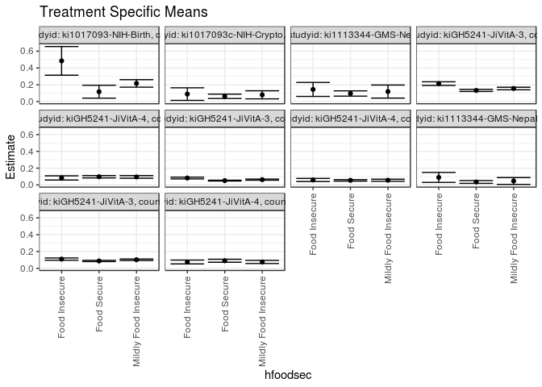

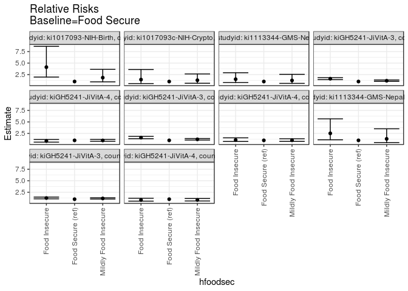

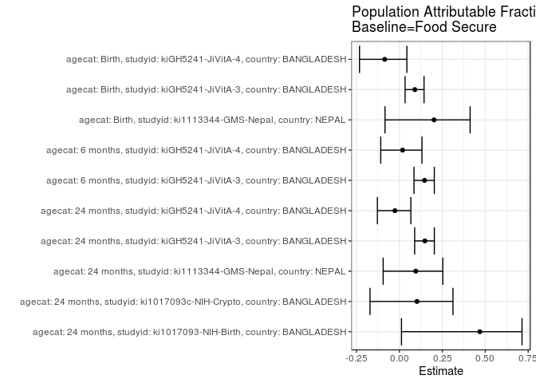

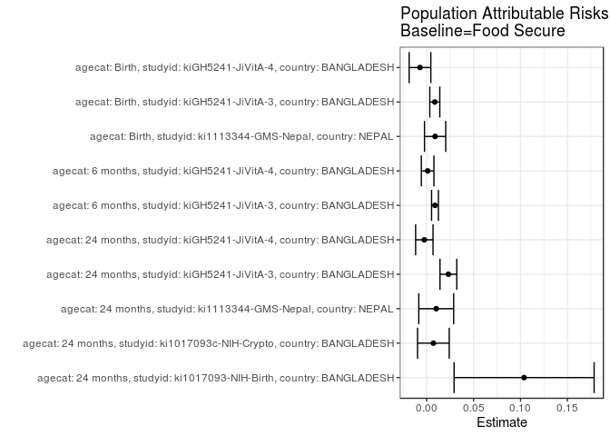

## Results Table

### Parameter: TSM

| agecat | studyid | country | intervention_level | baseline_level | estimate | ci_lower | ci_upper |
| --- | --- | --- | --- | --- | --- | --- | --- |
| Birth | ki1113344-GMS-Nepal | NEPAL | Food Secure | NA | 0.0356394 | 0.0189901 | 0.0522888 |
| Birth | ki1113344-GMS-Nepal | NEPAL | Mildly Food Insecure | NA | 0.0471698 | 0.0067813 | 0.0875584 |
| Birth | ki1113344-GMS-Nepal | NEPAL | Food Insecure | NA | 0.0898876 | 0.0304209 | 0.1493544 |
| Birth | kiGH5241-JiVitA-3 | BANGLADESH | Food Secure | NA | 0.0876133 | 0.0803919 | 0.0948347 |
| Birth | kiGH5241-JiVitA-3 | BANGLADESH | Mildly Food Insecure | NA | 0.1017019 | 0.0923024 | 0.1111013 |
| Birth | kiGH5241-JiVitA-3 | BANGLADESH | Food Insecure | NA | 0.1096215 | 0.0960378 | 0.1232051 |
| Birth | kiGH5241-JiVitA-4 | BANGLADESH | Food Secure | NA | 0.0900209 | 0.0720970 | 0.1079449 |
| Birth | kiGH5241-JiVitA-4 | BANGLADESH | Mildly Food Insecure | NA | 0.0756385 | 0.0570968 | 0.0941802 |
| Birth | kiGH5241-JiVitA-4 | BANGLADESH | Food Insecure | NA | 0.0752089 | 0.0523768 | 0.0980410 |
| 6 months | kiGH5241-JiVitA-3 | BANGLADESH | Food Secure | NA | 0.0518122 | 0.0469616 | 0.0566629 |
| 6 months | kiGH5241-JiVitA-3 | BANGLADESH | Mildly Food Insecure | NA | 0.0631917 | 0.0565245 | 0.0698589 |
| 6 months | kiGH5241-JiVitA-3 | BANGLADESH | Food Insecure | NA | 0.0825523 | 0.0718451 | 0.0932594 |
| 6 months | kiGH5241-JiVitA-4 | BANGLADESH | Food Secure | NA | 0.0548731 | 0.0459034 | 0.0638427 |
| 6 months | kiGH5241-JiVitA-4 | BANGLADESH | Mildly Food Insecure | NA | 0.0561018 | 0.0438111 | 0.0683925 |
| 6 months | kiGH5241-JiVitA-4 | BANGLADESH | Food Insecure | NA | 0.0594855 | 0.0410416 | 0.0779295 |
| 24 months | ki1017093-NIH-Birth | BANGLADESH | Food Secure | NA | 0.1176471 | 0.0409794 | 0.1943147 |
| 24 months | ki1017093-NIH-Birth | BANGLADESH | Mildly Food Insecure | NA | 0.2164634 | 0.1718424 | 0.2610845 |
| 24 months | ki1017093-NIH-Birth | BANGLADESH | Food Insecure | NA | 0.4848485 | 0.3141348 | 0.6555622 |
| 24 months | ki1017093c-NIH-Crypto | BANGLADESH | Food Secure | NA | 0.0628743 | 0.0368167 | 0.0889318 |
| 24 months | ki1017093c-NIH-Crypto | BANGLADESH | Mildly Food Insecure | NA | 0.0806452 | 0.0326728 | 0.1286175 |
| 24 months | ki1017093c-NIH-Crypto | BANGLADESH | Food Insecure | NA | 0.0892857 | 0.0145275 | 0.1640439 |
| 24 months | ki1113344-GMS-Nepal | NEPAL | Food Secure | NA | 0.0964912 | 0.0651656 | 0.1278169 |
| 24 months | ki1113344-GMS-Nepal | NEPAL | Mildly Food Insecure | NA | 0.1194030 | 0.0416778 | 0.1971281 |
| 24 months | ki1113344-GMS-Nepal | NEPAL | Food Insecure | NA | 0.1449275 | 0.0617789 | 0.2280762 |
| 24 months | kiGH5241-JiVitA-3 | BANGLADESH | Food Secure | NA | 0.1331613 | 0.1209224 | 0.1454002 |
| 24 months | kiGH5241-JiVitA-3 | BANGLADESH | Mildly Food Insecure | NA | 0.1557407 | 0.1405812 | 0.1709002 |
| 24 months | kiGH5241-JiVitA-3 | BANGLADESH | Food Insecure | NA | 0.2141952 | 0.1926103 | 0.2357801 |
| 24 months | kiGH5241-JiVitA-4 | BANGLADESH | Food Secure | NA | 0.0975406 | 0.0836927 | 0.1113886 |
| 24 months | kiGH5241-JiVitA-4 | BANGLADESH | Mildly Food Insecure | NA | 0.0956012 | 0.0799765 | 0.1112258 |
| 24 months | kiGH5241-JiVitA-4 | BANGLADESH | Food Insecure | NA | 0.0837438 | 0.0587678 | 0.1087199 |

### Parameter: E(Y)

| agecat | studyid | country | intervention_level | baseline_level | estimate | ci_lower | ci_upper |
| --- | --- | --- | --- | --- | --- | --- | --- |
| Birth | ki1113344-GMS-Nepal | NEPAL | NA | NA | 0.0446429 | 0.0290169 | 0.0602688 |
| Birth | kiGH5241-JiVitA-3 | BANGLADESH | NA | NA | 0.0962824 | 0.0908494 | 0.1017154 |
| Birth | kiGH5241-JiVitA-4 | BANGLADESH | NA | NA | 0.0829181 | 0.0711515 | 0.0946848 |
| 6 months | kiGH5241-JiVitA-3 | BANGLADESH | NA | NA | 0.0606873 | 0.0568242 | 0.0645503 |
| 6 months | kiGH5241-JiVitA-4 | BANGLADESH | NA | NA | 0.0559149 | 0.0491257 | 0.0627040 |
| 24 months | ki1017093-NIH-Birth | BANGLADESH | NA | NA | 0.2214452 | 0.1821080 | 0.2607825 |
| 24 months | ki1017093c-NIH-Crypto | BANGLADESH | NA | NA | 0.0700389 | 0.0479542 | 0.0921236 |
| 24 months | ki1113344-GMS-Nepal | NEPAL | NA | NA | 0.1066946 | 0.0789894 | 0.1343997 |
| 24 months | kiGH5241-JiVitA-3 | BANGLADESH | NA | NA | 0.1563185 | 0.1472145 | 0.1654224 |
| 24 months | kiGH5241-JiVitA-4 | BANGLADESH | NA | NA | 0.0950562 | 0.0854670 | 0.1046455 |

### Parameter: RR

| agecat | studyid | country | intervention_level | baseline_level | estimate | ci_lower | ci_upper |
| --- | --- | --- | --- | --- | --- | --- | --- |
| Birth | ki1113344-GMS-Nepal | NEPAL | Food Secure | Food Secure | 1.0000000 | 1.0000000 | 1.000000 |
| Birth | ki1113344-GMS-Nepal | NEPAL | Mildly Food Insecure | Food Secure | 1.3235294 | 0.4990314 | 3.510260 |
| Birth | ki1113344-GMS-Nepal | NEPAL | Food Insecure | Food Secure | 2.5221414 | 1.1221261 | 5.668880 |
| Birth | kiGH5241-JiVitA-3 | BANGLADESH | Food Secure | Food Secure | 1.0000000 | 1.0000000 | 1.000000 |
| Birth | kiGH5241-JiVitA-3 | BANGLADESH | Mildly Food Insecure | Food Secure | 1.1608041 | 1.0296678 | 1.308642 |
| Birth | kiGH5241-JiVitA-3 | BANGLADESH | Food Insecure | Food Secure | 1.2511966 | 1.0778050 | 1.452482 |
| Birth | kiGH5241-JiVitA-4 | BANGLADESH | Food Secure | Food Secure | 1.0000000 | 1.0000000 | 1.000000 |
| Birth | kiGH5241-JiVitA-4 | BANGLADESH | Mildly Food Insecure | Food Secure | 0.8402324 | 0.6126505 | 1.152354 |
| Birth | kiGH5241-JiVitA-4 | BANGLADESH | Food Insecure | Food Secure | 0.8354603 | 0.5801398 | 1.203148 |
| 6 months | kiGH5241-JiVitA-3 | BANGLADESH | Food Secure | Food Secure | 1.0000000 | 1.0000000 | 1.000000 |
| 6 months | kiGH5241-JiVitA-3 | BANGLADESH | Mildly Food Insecure | Food Secure | 1.2196291 | 1.0642499 | 1.397694 |
| 6 months | kiGH5241-JiVitA-3 | BANGLADESH | Food Insecure | Food Secure | 1.5932967 | 1.3587045 | 1.868393 |
| 6 months | kiGH5241-JiVitA-4 | BANGLADESH | Food Secure | Food Secure | 1.0000000 | 1.0000000 | 1.000000 |
| 6 months | kiGH5241-JiVitA-4 | BANGLADESH | Mildly Food Insecure | Food Secure | 1.0223924 | 0.7785173 | 1.342663 |
| 6 months | kiGH5241-JiVitA-4 | BANGLADESH | Food Insecure | Food Secure | 1.0840572 | 0.7610886 | 1.544078 |
| 24 months | ki1017093-NIH-Birth | BANGLADESH | Food Secure | Food Secure | 1.0000000 | 1.0000000 | 1.000000 |
| 24 months | ki1017093-NIH-Birth | BANGLADESH | Mildly Food Insecure | Food Secure | 1.8399390 | 0.9288873 | 3.644549 |
| 24 months | ki1017093-NIH-Birth | BANGLADESH | Food Insecure | Food Secure | 4.1212121 | 1.9648904 | 8.643937 |
| 24 months | ki1017093c-NIH-Crypto | BANGLADESH | Food Secure | Food Secure | 1.0000000 | 1.0000000 | 1.000000 |
| 24 months | ki1017093c-NIH-Crypto | BANGLADESH | Mildly Food Insecure | Food Secure | 1.2826421 | 0.6212197 | 2.648291 |
| 24 months | ki1017093c-NIH-Crypto | BANGLADESH | Food Insecure | Food Secure | 1.4200680 | 0.5579185 | 3.614494 |
| 24 months | ki1113344-GMS-Nepal | NEPAL | Food Secure | Food Secure | 1.0000000 | 1.0000000 | 1.000000 |
| 24 months | ki1113344-GMS-Nepal | NEPAL | Mildly Food Insecure | Food Secure | 1.2374491 | 0.5978826 | 2.561172 |
| 24 months | ki1113344-GMS-Nepal | NEPAL | Food Insecure | Food Secure | 1.5019762 | 0.7769123 | 2.903716 |
| 24 months | kiGH5241-JiVitA-3 | BANGLADESH | Food Secure | Food Secure | 1.0000000 | 1.0000000 | 1.000000 |
| 24 months | kiGH5241-JiVitA-3 | BANGLADESH | Mildly Food Insecure | Food Secure | 1.1695642 | 1.0261573 | 1.333012 |
| 24 months | kiGH5241-JiVitA-3 | BANGLADESH | Food Insecure | Food Secure | 1.6085394 | 1.4083425 | 1.837195 |
| 24 months | kiGH5241-JiVitA-4 | BANGLADESH | Food Secure | Food Secure | 1.0000000 | 1.0000000 | 1.000000 |
| 24 months | kiGH5241-JiVitA-4 | BANGLADESH | Mildly Food Insecure | Food Secure | 0.9801163 | 0.7909662 | 1.214499 |
| 24 months | kiGH5241-JiVitA-4 | BANGLADESH | Food Insecure | Food Secure | 0.8585533 | 0.6166659 | 1.195321 |

### Parameter: PAR

| agecat | studyid | country | intervention_level | baseline_level | estimate | ci_lower | ci_upper |
| --- | --- | --- | --- | --- | --- | --- | --- |
| Birth | ki1113344-GMS-Nepal | NEPAL | Food Secure | NA | 0.0090034 | -0.0023034 | 0.0203103 |
| Birth | kiGH5241-JiVitA-3 | BANGLADESH | Food Secure | NA | 0.0086691 | 0.0033381 | 0.0140000 |
| Birth | kiGH5241-JiVitA-4 | BANGLADESH | Food Secure | NA | -0.0071028 | -0.0186524 | 0.0044468 |
| 6 months | kiGH5241-JiVitA-3 | BANGLADESH | Food Secure | NA | 0.0088750 | 0.0052395 | 0.0125105 |
| 6 months | kiGH5241-JiVitA-4 | BANGLADESH | Food Secure | NA | 0.0010418 | -0.0056655 | 0.0077491 |
| 24 months | ki1017093-NIH-Birth | BANGLADESH | Food Secure | NA | 0.1037982 | 0.0292197 | 0.1783766 |
| 24 months | ki1017093c-NIH-Crypto | BANGLADESH | Food Secure | NA | 0.0071647 | -0.0096965 | 0.0240259 |
| 24 months | ki1113344-GMS-Nepal | NEPAL | Food Secure | NA | 0.0102033 | -0.0083620 | 0.0287687 |
| 24 months | kiGH5241-JiVitA-3 | BANGLADESH | Food Secure | NA | 0.0231572 | 0.0142040 | 0.0321104 |
| 24 months | kiGH5241-JiVitA-4 | BANGLADESH | Food Secure | NA | -0.0024844 | -0.0117524 | 0.0067836 |

### Parameter: PAF

| agecat | studyid | country | intervention_level | baseline_level | estimate | ci_lower | ci_upper |
| --- | --- | --- | --- | --- | --- | --- | --- |
| Birth | ki1113344-GMS-Nepal | NEPAL | Food Secure | NA | 0.2016771 | -0.0837182 | 0.4119141 |
| Birth | kiGH5241-JiVitA-3 | BANGLADESH | Food Secure | NA | 0.0900381 | 0.0332434 | 0.1434962 |
| Birth | kiGH5241-JiVitA-4 | BANGLADESH | Food Secure | NA | -0.0856602 | -0.2323599 | 0.0435764 |
| 6 months | kiGH5241-JiVitA-3 | BANGLADESH | Food Secure | NA | 0.1462421 | 0.0850540 | 0.2033381 |
| 6 months | kiGH5241-JiVitA-4 | BANGLADESH | Food Secure | NA | 0.0186323 | -0.1086877 | 0.1313310 |
| 24 months | ki1017093-NIH-Birth | BANGLADESH | Food Secure | NA | 0.4687307 | 0.0121611 | 0.7142782 |
| 24 months | ki1017093c-NIH-Crypto | BANGLADESH | Food Secure | NA | 0.1022954 | -0.1713644 | 0.3120215 |
| 24 months | ki1113344-GMS-Nepal | NEPAL | Food Secure | NA | 0.0956312 | -0.0945510 | 0.2527686 |
| 24 months | kiGH5241-JiVitA-3 | BANGLADESH | Food Secure | NA | 0.1481411 | 0.0889516 | 0.2034851 |
| 24 months | kiGH5241-JiVitA-4 | BANGLADESH | Food Secure | NA | -0.0261363 | -0.1282308 | 0.0667196 |